# Rare Diseases in the Duke Medical System

Gary Koplik, Matt Tribby

This document is meant to summarize all of our work so far with the Duke Medical System data.

### Manipulating our Data and Partioning into Rare Disease Patients / Non-Rare Disease Patients

Our data started out in a wide format. Here is some toy data as an example:

| PATID | VISIT | SEX | AGE | ICD-9 | ICD-10 |
| --- | --- | --- | --- | --- | --- |
| Z111111 | OCT-2013 | M | 55 | 250.00, 759.89 | E11.9, E74.02 |
| Z222222 | JUL-2014 | F | 32 | 315.01 | E83.01, E78.2 |

We had two additional columns called `DX GROUP` and `LABEL`, but since we are unclear on what exact information these columns are specifying (it has some proprietary implications within the EPIC software system that Duke uses), we’ve chosen to disregard them for now.

We first converted the data from this wide format to a long format. By our data maniplulation, the toy example becomes:

| PATID | VISIT | SEX | AGE | TERMINOLOGY | CODE |
| --- | --- | --- | --- | --- | --- |
| Z111111 | OCT-2013 | M | 55 | ICD-9 | 250.00 |
| Z111111 | OCT-2013 | M | 55 | ICD-9 | 759.89 |
| Z111111 | OCT-2013 | M | 55 | ICD-10 | E11.9 |
| Z111111 | OCT-2013 | M | 55 | ICD-10 | E74.02 |
| Z222222 | JUL-2014 | F | 32 | ICD-9 | 315.01 |
| Z222222 | JUL-2014 | F | 32 | ICD-10 | E83.01 |
| Z222222 | JUL-2014 | F | 32 | ICD-10 | E78.2 |

Next, we partitioned our data into patients with a rare disease and patients without a rare disease. In order to be classified as a rare disease patient, the patient needed to exhibit one or more codes from our list of ICD-9 and ICD-10 codes that map to a rare disease. If a patient had at least one rare disease code, then we include *all* of that patient’s long form rows in the rare patients file. All other patients’ rows were placed in the non-rare patients file.

*Note: we know this is by no means a perfect way of partitioning our data due in part to potential misdiagnoses (i.e. maybe we should require more than one instance of a rare disease code to classify patients as rare), which we have yet to explore. More significantly, many of the “rare” ICD codes map to both rare **and** non-rare diseases, which we will discuss further later.*

### Summary Statistics

Here, we include some summary statistics from our data set.

**Number of Unique Patients**: 1245243

**Number of Unique Rare Patients**: 731121

**Number of Unique Rare Patients Based Solely on ICD9**: 680559

**Number of Unique Rare Patients Based Solely on ICD10**: 580952

**Length of Intersection of those two**: 530390

**Number of Unique Non-Rare Patients**: 514122

**Unique number of rare ICD9 codes**: 1401

**Unique number of rare ICD10 codes**: 1585

**Proportion of Rare Codes over Total Codes ICD9**: 0.2148471

**Proportion of Rare Codes over Total Codes ICD10**: 0.1667331

### Looking at Prevalence of Rare Diseases

Here, we started with the subset of patients that at one point were assigned at least one ICD-9 or ICD-10 code of a rare disease (from the mappings).

We then filtered these data to only keep the rows containing a rare disease ICD code (remember, we have restructured the data such that there is only one ICD-9 or ICD-10 code per row).

We finally further filtered these data such that the combination of patient ID and ICD code was unique / a primary key in this final data frame (for example, if a patient has cystic fibrosis with the specified ICD code in a visit in October of 2012 and shows the same code in October of 2013, then one of these rows will be deleted). I did this to avoid double counting patients with respect to determining prevalence of rare diseases in this data set. *Note, we can go back later to look **only** at patients who are assigned a rare disease code more than once, which is likely a more robust indication of whether a patient has a rare disease vs possibly having a rare disease*.

### Graphs Using All Rare Disease Codes

These figures show the top 20 ICD-9 codes and ICD-10 codes by frequency. Here, we used all ICD codes contained in the files from the National Library of Medicine. Rather than show the ICD codes on the y-axis, we have replaced those values with the ICD code descriptions from the files from the NLM.

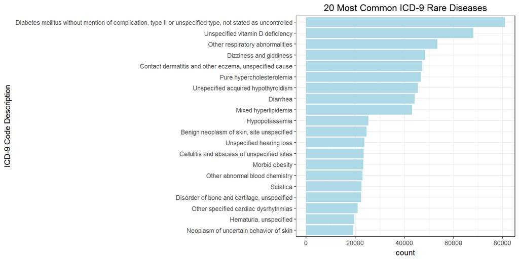

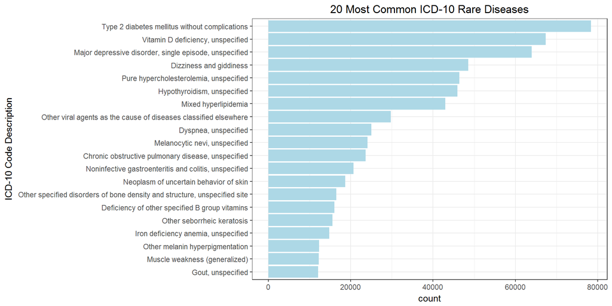

Given the names that are showing up here, in particular Type II Diabetes, clearly there are issues we should further explore. Since the mappings between these ICD codes are not necessarily 1 ICD code to 1 disease (some are 1 ICD code to many diseases), we will not discuss which diseases are mapping to these codes with these graphs.

In the next section, however, we address this discrepancy between ICD code and rare disease name by including tables of the ICD code and the unique rare disease to which it maps. Since the Diabetes issue resurfaces there, this specific example will be further discussed momentarily.

### Graphs with Only 1 Rare Disease per Code

Here, we specifically looked at only ICD codes that uniquely mapped to exactly one “rare” disease in our mapping files.

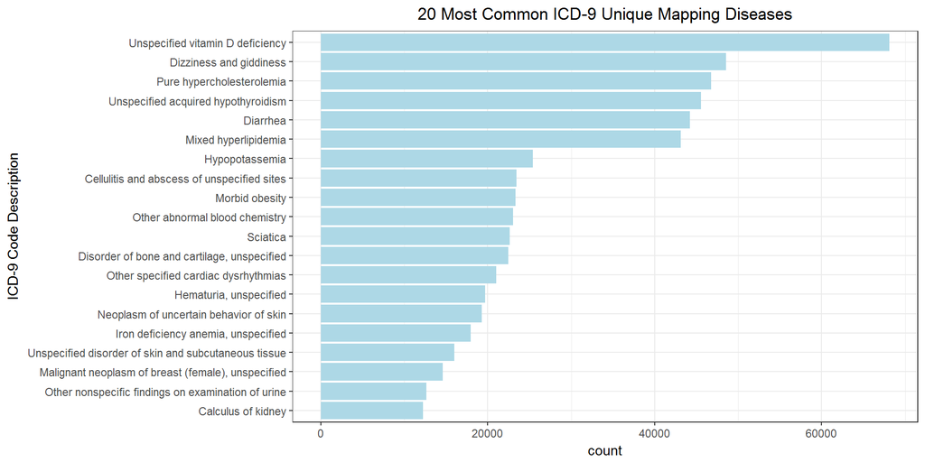

| ICD-9 Code | Rare Disease Name | Code Description |
| --- | --- | --- |
| 268.9 | Rickets | Unspecified vitamin D deficiency |
| 780.4 | Dysequilibrium syndrome | Dizziness and giddiness |
| 272.0 | Hyperlipoproteinemia type 2 | Pure hypercholesterolemia |
| 244.9 | Thyrotropin deficiency, isolated | Unspecified acquired hypothyroidism |
| 787.91 | Immunodysregulation, polyendocrinopathy and enteropathy X-linked | Diarrhea |
| 272.2 | Hyperlipidemia type 3 | Mixed hyperlipidemia |
| 276.8 | Gitelman syndrome | Hypopotassemia |
| 682.9 | Wells syndrome | Cellulitis and abscess of unspecified sites |
| 278.01 | Proopiomelanocortin deficiency | Morbid obesity |
| 790.6 | Renal hypouricemia | Other abnormal blood chemistry |
| 724.3 | Piriformis syndrome | Sciatica |
| 733.90 | Spondyloenchondrodysplasia | Disorder of bone and cartilage, unspecified |
| 427.89 | His bundle tachycardia | Other specified cardiac dysrhythmias |
| 599.70 | Loin pain hematuria syndrome | Hematuria, unspecified |
| 238.2 | Muir-Torre syndrome | Neoplasm of uncertain behavior of skin |
| 280.9 | Iron-refractory iron deficiency anemia | Iron deficiency anemia, unspecified |
| 709.9 | Tight skin contracture syndrome, lethal | Unspecified disorder of skin and subcutaneous tissue |
| 174.9 | Inflammatory breast cancer | Malignant neoplasm of breast (female), unspecified |
| 791.9 | 3-Hydroxyisobutyric aciduria | Other nonspecific findings on examination of urine |
| 592.0 | Dent disease | Calculus of kidney |

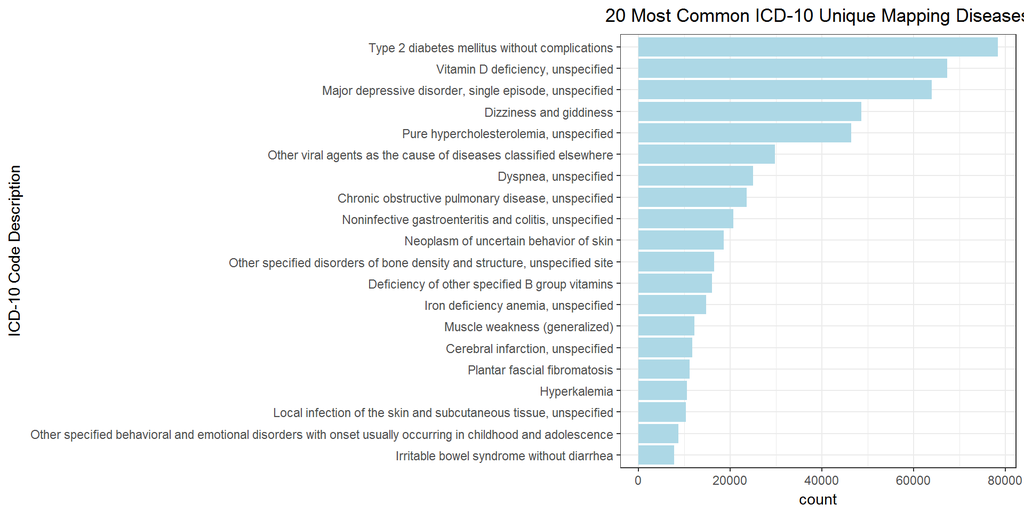

| ICD-10 Code | Rare Disease Name | Code Description |
| --- | --- | --- |
| E11.9 | Maturity-onset diabetes of the young, type 2 | Type 2 diabetes mellitus without complications |
| E55.9 | Rickets | Vitamin D deficiency, unspecified |
| F32.9 | Mal de debarquement | Major depressive disorder, single episode, unspecified |
| R42 | Dysequilibrium syndrome | Dizziness and giddiness |
| E78.00 | Hyperlipoproteinemia type 2 | Pure hypercholesterolemia, unspecified |
| B97.89 | Togaviridae disease | Other viral agents as the cause of diseases classified elsewhere |
| R06.00 | Paraneoplastic Neurologic Disorders | Dyspnea, unspecified |
| J44.9 | Bronchiolitis obliterans | Chronic obstructive pulmonary disease, unspecified |
| K52.9 | WDHA syndrome | Noninfective gastroenteritis and colitis, unspecified |
| D48.5 | Dermatofibrosarcoma protuberans | Neoplasm of uncertain behavior of skin |
| M85.80 | Melorheostosis | Other specified disorders of bone density and structure, unspecified site |
| E53.8 | Biotinidase deficiency | Deficiency of other specified B group vitamins |
| D50.9 | Iron-refractory iron deficiency anemia | Iron deficiency anemia, unspecified |
| M62.81 | Neuropathy ataxia retinitis pigmentosa syndrome | Muscle weakness (generalized) |
| I63.9 | Neonatal stroke | Cerebral infarction, unspecified |
| M72.2 | Ledderhose disease | Plantar fascial fibromatosis |
| E87.5 | Gordon syndrome | Hyperkalemia |
| L08.9 | Erosive pustular dermatosis of the scalp | Local infection of the skin and subcutaneous tissue, unspecified |
| F98.8 | Psychosocial short stature | Other specified behavioral and emotional disorders with onset usually occurring in childhood and adolescence |
| K58.9 | Ichthyosis bullosa of Siemens | Irritable bowel syndrome without diarrhea |

### Back to the Diabetes Example

The issue of rare vs. not rare for all of these cases goes well beyond my domain knowledge, but we do know that Type II Diabetes isn’t exactly rare.

Since the distinguishing factor for the rareness of diabetes is age, here we include a kernel density plot of age of patients with the ICD-10 code for Type II Diabetes (E11.9) in our rare patients data set (78,370 patients in this subset). According to [this NCBI article](https://www.ncbi.nlm.nih.gov/pmc/articles/PMC3363133), 63% of cases present by age 25, 79% by age 35, and 96% by age 55. Although this density plot is by no means causal proof, it appears highly unlikely that this age distribution would represent such a cohort independent of other Diabetes cases:

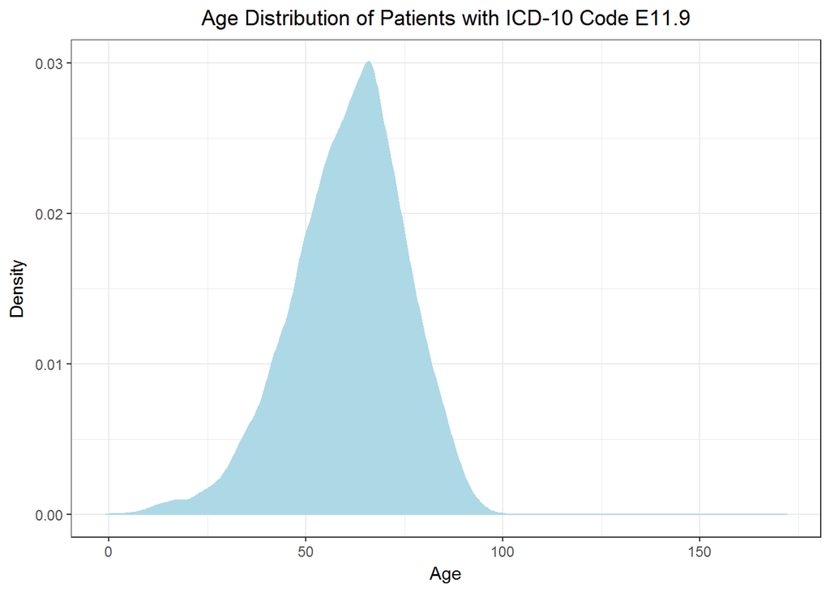

### The Takeaway

As we can see from these tables, we have a recurring issue of rare diseases being grouped together with more common diseases under both ICD-9 and ICD-10, and looking at diseases that have unique mappings with respect to our rare disease data set clearly is not sufficient to guarantee that we only look at patients with true rare diseases.

Most notably, we need to address the question:

*How useful are our mappings with respect to quantifying the burden of rare disease on the Duke Medical System, and how can we best subset the mapping relationships we have such that we can be sure to look at a **true** subset of rare disease patients in the Duke Medical Sytem?*

It’s unclear at this point whether / how much of this issue is the result of mapping diseases to ICD codes by “walking up” the hierarchy and how much is the result of the “for billing” nature to the ICD hierarchy. For example, the Type II Diabetes issue presented here is an example of the latter problem, with the ICD-10 code E11.9 incorporating other forms of Diabetes into it.

Regardless of the cause of the problem, we believe this is the most important issue standing between us and our goal of quantifying the burden of rare disease.

### Frequency Table with All ICD-10 Codes for Rare Diseases

This table shows the frequency of all ICD-10 codes in our rare disease file (from the National Library of Medicine). We also include the ICD-10 code description as well as the name of the disease it maps to in our mapping file.

Number of ICD-10 Codes: **3166**

Total Number of Patients: **2338429**

| ICD-10 Code | Frequency | Rare Disease Name | ICD Code Description |
| --- | --- | --- | --- |
| E11.9 | 78370 | Maturity-onset diabetes of the young, type 2 | Type 2 diabetes mellitus without complications |
| E55.9 | 67357 | Rickets | Vitamin D deficiency, unspecified |
| F32.9 | 63921 | Mal de debarquement | Major depressive disorder, single episode, unspecified |
| R42 | 48568 | Dysequilibrium syndrome | Dizziness and giddiness |
| E78.00 | 46355 | Hyperlipoproteinemia type 2 | Pure hypercholesterolemia, unspecified |
| E03.9 | 45959 | Kocher-Debre-Semelaigne syndrome | Hypothyroidism, unspecified |
| E03.9 | 45959 | Thyrotropin deficiency, isolated | Hypothyroidism, unspecified |
| E78.2 | 42956 | Hyperlipidemia type 3 | Mixed hyperlipidemia |
| E78.2 | 42956 | Xanthoma disseminatum | Mixed hyperlipidemia |
| B97.89 | 29781 | Togaviridae disease | Other viral agents as the cause of diseases classified elsewhere |
| R06.00 | 25025 | Paraneoplastic Neurologic Disorders | Dyspnea, unspecified |
| D22.9 | 24067 | Basaloid follicular hamartoma | Melanocytic nevi, unspecified |
| D22.9 | 24067 | Giant congenital nevus | Melanocytic nevi, unspecified |
| D22.9 | 24067 | Becker’s nevus | Melanocytic nevi, unspecified |
| D22.9 | 24067 | Pseudoxanthoma elasticum | Melanocytic nevi, unspecified |
| D22.9 | 24067 | Linear nevus sebaceous syndrome | Melanocytic nevi, unspecified |
| J44.9 | 23648 | Bronchiolitis obliterans | Chronic obstructive pulmonary disease, unspecified |
| K52.9 | 20685 | WDHA syndrome | Noninfective gastroenteritis and colitis, unspecified |
| D48.5 | 18678 | Dermatofibrosarcoma protuberans | Neoplasm of uncertain behavior of skin |
| M85.80 | 16522 | Melorheostosis | Other specified disorders of bone density and structure, unspecified site |
| E53.8 | 16024 | Biotinidase deficiency | Deficiency of other specified B group vitamins |
| D50.9 | 14805 | Iron-refractory iron deficiency anemia | Iron deficiency anemia, unspecified |
| L81.4 | 12369 | Carbon baby syndrome | Other melanin hyperpigmentation |
| L81.4 | 12369 | Linear and whorled nevoid hypermelanosis | Other melanin hyperpigmentation |
| M62.81 | 12278 | Neuropathy ataxia retinitis pigmentosa syndrome | Muscle weakness (generalized) |
| M10.9 | 12098 | Gouty nephropathy, familial | Gout, unspecified |
| M10.9 | 12098 | Familial juvenile hyperuricaemic nephropathy | Gout, unspecified |
| M10.9 | 12098 | Autosomal dominant medullary cystic kidney disease with hyperuricemia | Gout, unspecified |
| I63.9 | 11807 | Neonatal stroke | Cerebral infarction, unspecified |
| M72.2 | 11148 | Ledderhose disease | Plantar fascial fibromatosis |

[output cut: 3136 more lines]

### Frequency Table of ICD-10 Codes that Each Only Map to Exactly 1 Rare Disease

Here, we specifically looked at only ICD-10 codes that uniquely mapped to exactly one “rare” disease in our mapping files.

Number of ICD-10 Codes: **1029**

Total Number of Patients: **934264**

| ICD-10 Code | Frequency | Rare Disease Name | ICD Code Description |
| --- | --- | --- | --- |
| E11.9 | 78370 | Maturity-onset diabetes of the young, type 2 | Type 2 diabetes mellitus without complications |
| E55.9 | 67357 | Rickets | Vitamin D deficiency, unspecified |
| F32.9 | 63921 | Mal de debarquement | Major depressive disorder, single episode, unspecified |
| R42 | 48568 | Dysequilibrium syndrome | Dizziness and giddiness |
| E78.00 | 46355 | Hyperlipoproteinemia type 2 | Pure hypercholesterolemia, unspecified |
| B97.89 | 29781 | Togaviridae disease | Other viral agents as the cause of diseases classified elsewhere |
| R06.00 | 25025 | Paraneoplastic Neurologic Disorders | Dyspnea, unspecified |
| J44.9 | 23648 | Bronchiolitis obliterans | Chronic obstructive pulmonary disease, unspecified |
| K52.9 | 20685 | WDHA syndrome | Noninfective gastroenteritis and colitis, unspecified |
| D48.5 | 18678 | Dermatofibrosarcoma protuberans | Neoplasm of uncertain behavior of skin |
| M85.80 | 16522 | Melorheostosis | Other specified disorders of bone density and structure, unspecified site |
| E53.8 | 16024 | Biotinidase deficiency | Deficiency of other specified B group vitamins |
| D50.9 | 14805 | Iron-refractory iron deficiency anemia | Iron deficiency anemia, unspecified |
| M62.81 | 12278 | Neuropathy ataxia retinitis pigmentosa syndrome | Muscle weakness (generalized) |
| I63.9 | 11807 | Neonatal stroke | Cerebral infarction, unspecified |
| M72.2 | 11148 | Ledderhose disease | Plantar fascial fibromatosis |
| E87.5 | 10605 | Gordon syndrome | Hyperkalemia |
| L08.9 | 10432 | Erosive pustular dermatosis of the scalp | Local infection of the skin and subcutaneous tissue, unspecified |
| F98.8 | 8735 | Psychosocial short stature | Other specified behavioral and emotional disorders with onset usually occurring in childhood and adolescence |
| K58.9 | 7800 | Ichthyosis bullosa of Siemens | Irritable bowel syndrome without diarrhea |
| H53.8 | 7657 | Bradyopsia | Other visual disturbances |
| I47.1 | 7305 | His bundle tachycardia | Supraventricular tachycardia |
| M53.3 | 7125 | Coccygodynia | Sacrococcygeal disorders, not elsewhere classified |
| E78.1 | 7041 | Hyperlipoproteinemia type 4 | Pure hyperglyceridemia |
| E83.42 | 6761 | Primary hypomagnesemia with secondary hypocalcemia | Hypomagnesemia |
| R33.9 | 5974 | Fowler’s syndrome | Retention of urine, unspecified |
| L29.8 | 5920 | Aquagenic pruritus | Other pruritus |
| R06.89 | 5625 | Congenital central hypoventilation syndrome | Other abnormalities of breathing |
| E83.52 | 5433 | Familial hypocalciuric hypercalcemia | Hypercalcemia |
| D50.8 | 5173 | Hypochromic microcytic anemia with iron overload | Other iron deficiency anemias |

[output cut: 999 more lines]

### Frequency Table with All ICD-10 Codes for Rare Metabolic Diseases

This table shows the frequency of all rare metabolic disease ICD-10 codes from our rare disease file (from the National Library of Medicine). We also include the ICD-10 code description as well as the name of the rare metabolic disease it maps to in our mapping file.

Number of ICD-10 Codes: **429**

Total Number of Patients: **231182**

| ICD-10 Code | Frequency | Rare Disease Name | ICD Code Description |
| --- | --- | --- | --- |
| E78.00 | 46355 | Hyperlipoproteinemia type 2 | Pure hypercholesterolemia, unspecified |
| E78.2 | 42956 | Hyperlipidemia type 3 | Mixed hyperlipidemia |
| E78.2 | 42956 | Xanthoma disseminatum | Mixed hyperlipidemia |
| E87.5 | 10605 | Gordon syndrome | Hyperkalemia |
| E78.1 | 7041 | Hyperlipoproteinemia type 4 | Pure hyperglyceridemia |
| E83.42 | 6761 | Primary hypomagnesemia with secondary hypocalcemia | Hypomagnesemia |
| E83.52 | 5433 | Familial hypocalciuric hypercalcemia | Hypercalcemia |
| E88.81 | 4269 | Insulin-resistance type B | Metabolic syndrome |
| E88.81 | 4269 | Abdominal obesity metabolic syndrome | Metabolic syndrome |
| E80.6 | 3459 | Rotor syndrome | Other disorders of bilirubin metabolism |
| E80.6 | 3459 | Dubin-Johnson syndrome | Other disorders of bilirubin metabolism |
| E83.51 | 2020 | Hypocalcemia, autosomal dominant | Hypocalcemia |
| E88.09 | 1763 | Pseudocholinesterase deficiency | Other disorders of plasma-protein metabolism, not elsewhere classified |
| E88.09 | 1763 | Pseudocholinesterase deficiency | Other disorders of plasma-protein metabolism, not elsewhere classified |
| E88.09 | 1763 | Atransferrinemia | Other disorders of plasma-protein metabolism, not elsewhere classified |
| E88.09 | 1763 | Congenital analbuminemia | Other disorders of plasma-protein metabolism, not elsewhere classified |
| E78.6 | 1704 | Abetalipoproteinemia | Lipoprotein deficiency |
| E78.6 | 1704 | Familial HDL deficiency | Lipoprotein deficiency |
| E78.6 | 1704 | Familial hypobetalipoproteinemia | Lipoprotein deficiency |
| E78.6 | 1704 | Chorea-acanthocytosis | Lipoprotein deficiency |
| E78.6 | 1704 | Familial LCAT deficiency | Lipoprotein deficiency |
| E78.6 | 1704 | Fish-eye disease | Lipoprotein deficiency |
| E78.6 | 1704 | Tangier disease | Lipoprotein deficiency |
| E78.6 | 1704 | Hypolipoproteinemia | Lipoprotein deficiency |
| E78.6 | 1704 | Neuroacanthocytosis | Lipoprotein deficiency |
| E83.39 | 942 | Hypophosphatasia | Other disorders of phosphorus metabolism |
| E83.39 | 942 | Childhood hypophosphatasia | Other disorders of phosphorus metabolism |
| E78.89 | 749 | Lipoid proteinosis of Urbach and Wiethe | Other lipoprotein metabolism disorders |
| E78.89 | 749 | Farber’s disease | Other lipoprotein metabolism disorders |
| E78.89 | 749 | Sitosterolemia | Other lipoprotein metabolism disorders |

[output cut: 399 more lines]

### Frequency Table of ICD-10 Codes that Each Only Map to Exactly 1 Rare Metabolic Disease

Here, we specifically looked at only ICD-10 codes that uniquely mapped to exactly one “rare” metabolic disease in our mapping files.

Number of ICD-10 Codes: **63**

Total Number of Patients: **81193**

| ICD-10 Code | Frequency | Rare Disease Name | ICD Code Description |
| --- | --- | --- | --- |
| E78.00 | 46355 | Hyperlipoproteinemia type 2 | Pure hypercholesterolemia, unspecified |
| E87.5 | 10605 | Gordon syndrome | Hyperkalemia |
| E78.1 | 7041 | Hyperlipoproteinemia type 4 | Pure hyperglyceridemia |
| E83.42 | 6761 | Primary hypomagnesemia with secondary hypocalcemia | Hypomagnesemia |
| E83.52 | 5433 | Familial hypocalciuric hypercalcemia | Hypercalcemia |
| E83.51 | 2020 | Hypocalcemia, autosomal dominant | Hypocalcemia |
| E84.9 | 541 | Cystic fibrosis | Cystic fibrosis, unspecified |
| E78.01 | 535 | Hyperlipoproteinemia type 2 | Familial hypercholesterolemia |
| E75.21 | 345 | Fabry disease | Fabry (-Anderson) disease |
| E72.20 | 302 | Urea cycle disorders | Disorder of urea cycle metabolism, unspecified |
| E80.4 | 296 | Congenital nonhemolytic jaundice | Gilbert syndrome |
| E88.01 | 272 | Alpha-1 antitrypsin deficiency | Alpha-1-antitrypsin deficiency |
| E83.31 | 58 | Hypophosphatemic rickets | Familial hypophosphatemia |
| E70.329 | 57 | Oculocutaneous albinism | Oculocutaneous albinism, unspecified |
| E83.01 | 49 | Wilson disease | Wilson’s disease |
| E76.01 | 48 | Hurler syndrome | Hurler’s syndrome |
| E72.01 | 40 | Cystinuria | Cystinuria |
| E70.30 | 39 | Albinism | Albinism, unspecified |
| E76.3 | 38 | Mucopolysaccharidosis | Mucopolysaccharidosis, unspecified |
| E75.23 | 31 | Krabbe disease | Krabbe disease |
| E74.03 | 29 | Glycogen storage disease type 3 | Cori disease |
| E74.39 | 28 | Glucose-galactose malabsorption | Other disorders of intestinal carbohydrate absorption |
| E88.41 | 22 | Mitochondrial encephalomyopathy lactic acidosis and stroke-like episodes | MELAS syndrome |
| E71.311 | 22 | Medium-chain acyl-coenzyme A dehydrogenase deficiency | Medium chain acyl CoA dehydrogenase deficiency |
| E74.04 | 20 | Glycogen storage disease type 5 | McArdle disease |
| E72.51 | 15 | Glycine encephalopathy | Non-ketotic hyperglycinemia |
| E85.2 | 13 | Primary cutaneous amyloidosis | Heredofamilial amyloidosis, unspecified |
| E83.09 | 13 | Menkes disease | Other disorders of copper metabolism |
| E71.313 | 13 | Glutaric acidemia type II | Glutaric aciduria type II |
| E71.0 | 11 | Maple syrup urine disease | Maple-syrup-urine disease |
| E70.320 | 11 | Oculocutaneous albinism type 1 | Tyrosinase negative oculocutaneous albinism |
| E72.03 | 9 | Lowe oculocerebrorenal syndrome | Lowe’s syndrome |
| E71.50 | 9 | Peroxisomal biogenesis disorders | Peroxisomal disorder, unspecified |
| E85.0 | 8 | Amyloidosis familial visceral | Non-neuropathic heredofamilial amyloidosis |
| E71.121 | 8 | Propionic acidemia | Propionic acidemia |
| E70.331 | 8 | Hermansky-Pudlak syndrome | Hermansky-Pudlak syndrome |
| E78.72 | 6 | Smith-Lemli-Opitz syndrome | Smith-Lemli-Opitz syndrome |
| E70.0 | 6 | Phenylketonuria | Classical phenylketonuria |
| E83.89 | 5 | Hypermanganesemia with dystonia polycythemia and cirrhosis | Other disorders of mineral metabolism |
| E75.249 | 5 | Niemann-Pick disease type A | Niemann-Pick disease, unspecified |
| E72.10 | 5 | Megaloblastic anemia due to dihydrofolate reductase deficiency | Disorders of sulfur-bearing amino-acid metabolism, unspecified |
| E71.522 | 5 | Adrenomyeloneuropathy | Adrenomyeloneuropathy |
| E71.440 | 5 | Bannayan-Riley-Ruvalcaba syndrome | Ruvalcaba-Myhre-Smith syndrome |
| E70.310 | 5 | Ocular albinism type 1 | X-linked ocular albinism |
| E83.2 | 4 | Acrodermatitis enteropathica | Disorders of zinc metabolism |
| E79.2 | 4 | Adenosine monophosphate deaminase 1 deficiency | Myoadenylate deaminase deficiency |
| E76.210 | 4 | Mucopolysaccharidosis type IVA | Morquio A mucopolysaccharidoses |
| E75.02 | 4 | Tay-Sachs disease | Tay-Sachs disease |
| E72.52 | 4 | Trimethylaminuria | Trimethylaminuria |
| E77.0 | 3 | Mucolipidosis III alpha/beta | Defects in post-translational modification of lysosomal enzymes |
| E72.21 | 3 | Arginase deficiency | Argininemia |
| E70.330 | 3 | Chediak-Higashi syndrome | Chediak-Higashi syndrome |
| E76.02 | 2 | HurlerÎ“ÇôScheie syndrome | Hurler-Scheie syndrome |
| E74.29 | 2 | Galactokinase deficiency | Other disorders of galactose metabolism |
| E74.12 | 2 | Hereditary fructose intolerance | Hereditary fructose intolerance |
| E72.02 | 2 | Hartnup disease | Hartnup’s disease |
| E71.528 | 2 | Pseudoneonatal adrenoleukodystrophy | Other X-linked adrenoleukodystrophy |
| E71.110 | 2 | Isovaleric acidemia | Isovaleric acidemia |
| E78.81 | 1 | Multicentric reticulohistiocytosis | Lipoid dermatoarthritis |
| E76.03 | 1 | Scheie syndrome | Scheie’s syndrome |
| E75.241 | 1 | Niemann-Pick disease type B | Niemann-Pick disease type B |
| E75.01 | 1 | Sandhoff disease | Sandhoff disease |
| E71.510 | 1 | Zellweger syndrome | Zellweger syndrome |

$\hspace{4ex} _\blacksquare$